# Title: Cars sales in United kingdom

##### Name: Vamshidhar Reddy Peesu

##### GH No: GH1045870

##### Subject: AI and Applications (M504)

Link of the dataset: https://www.kaggle.com/datasets/msnbehdani/mock-dataset-of-second-hand-car-sales

GitHub link: https://github.com/vamshidharreddypeesu-collab/Cars-Sales-in-United-Kingdom-.git

Direct link to access dataset from google drive: https://drive.google.com/file/d/1PD8jSKnSLgDjasJcvyyxAaqIxOuvpSUh/view?usp=sharing

Screen Recording video Link: https://drive.google.com/file/d/1KDIZa2ALm0JZnjO_Sqp2ssbnaR12RwC-/view?usp=sharing

### The Problem is about?

Understanding usedcar sales patterns from different manufacturers, different models and fuel types over a multi-decade period. Which type of vehicle gives how much milage and which sized engine costs more

#### The Business questions are:

1. What is the totoal revenue Generated by car sales?
2. which fuel type had highest cars sales ?
3. which brand or manufacture sold more cars ?
4. What is the milage share of hybrid car models ?
5. which car gives more milage costly or affordable ?
6. what are the top 5 car models sold among all brands ?
7. what are correlation between engine size and milage and other variables ?
8. what is the total revenue generated by each Brand ?

#### Business Problem :

BMW and Porsche are wanted to increase car sales. According to the cars sales data Porsche and BMW manufacturers sold very less units of cars but ford and VW sold highest number of cars because the ford and VW manufacturing the cars with smaller engines and higher milage but the porsche manufacturing bigger engine cars with less milage. How can porsche and BMW can increase the sale? which kind of cars should they manufacture to get more sales?

A car dealer wants to expand his business he want whichs cars sales more and he also wants to know about the which car produce more milage affordable cars and he also wants to know about which type of cars does people prefer to buy. he want to knows how much revenue he genearted from last decade. he want some suggeston to expand their business

#### Importing Python Libraries

```python
import numpy as np
import pandas as pd
import seaborn as sns
from scipy import stats
import matplotlib.pyplot as plt
import warnings
warnings.simplefilter(action='ignore', category=FutureWarning)
```

#### Loading Dataset

```python
df=pd.read_csv(r"C:\Users\vpees\Downloads\car_sales_data.csv")
```

```python
df
```

|  | Manufacturer | Model | Engine size | Fuel type | Year of manufacture | Mileage | Price |
| --- | --- | --- | --- | --- | --- | --- | --- |
| 0 | Ford | Fiesta | 1.0 | Petrol | 2002 | 127300 | 3074 |
| 1 | Porsche | 718 Cayman | 4.0 | Petrol | 2016 | 57850 | 49704 |
| 2 | Ford | Mondeo | 1.6 | Diesel | 2014 | 39190 | 24072 |
| 3 | Toyota | RAV4 | 1.8 | Hybrid | 1988 | 210814 | 1705 |
| 4 | VW | Polo | 1.0 | Petrol | 2006 | 127869 | 4101 |
| ... | ... | ... | ... | ... | ... | ... | ... |
| 49995 | BMW | M5 | 5.0 | Petrol | 2018 | 28664 | 113006 |
| 49996 | Toyota | Prius | 1.8 | Hybrid | 2003 | 105120 | 9430 |
| 49997 | Ford | Mondeo | 1.6 | Diesel | 2022 | 4030 | 49852 |
| 49998 | Ford | Focus | 1.0 | Diesel | 2016 | 26468 | 23630 |
| 49999 | VW | Golf | 1.4 | Diesel | 2012 | 109300 | 10400 |

50000 rows × 7 columns

#### Displaying first few rows

```python
df.head()
```

|  | Manufacturer | Model | Engine size | Fuel type | Year of manufacture | Mileage | Price |
| --- | --- | --- | --- | --- | --- | --- | --- |
| 0 | Ford | Fiesta | 1.0 | Petrol | 2002 | 127300 | 3074 |
| 1 | Porsche | 718 Cayman | 4.0 | Petrol | 2016 | 57850 | 49704 |
| 2 | Ford | Mondeo | 1.6 | Diesel | 2014 | 39190 | 24072 |
| 3 | Toyota | RAV4 | 1.8 | Hybrid | 1988 | 210814 | 1705 |
| 4 | VW | Polo | 1.0 | Petrol | 2006 | 127869 | 4101 |

#### Displaying last five rows

```python
df.tail()
```

|  | Manufacturer | Model | Engine size | Fuel type | Year of manufacture | Mileage | Price |
| --- | --- | --- | --- | --- | --- | --- | --- |
| 49995 | BMW | M5 | 5.0 | Petrol | 2018 | 28664 | 113006 |
| 49996 | Toyota | Prius | 1.8 | Hybrid | 2003 | 105120 | 9430 |
| 49997 | Ford | Mondeo | 1.6 | Diesel | 2022 | 4030 | 49852 |
| 49998 | Ford | Focus | 1.0 | Diesel | 2016 | 26468 | 23630 |
| 49999 | VW | Golf | 1.4 | Diesel | 2012 | 109300 | 10400 |

#### Displaying datatypes of each column

```python
df.dtypes
```

```
Manufacturer            object
Model                   object
Engine size            float64
Fuel type               object
Year of manufacture      int64
Mileage                  int64
Price                    int64
dtype: object
```

#### Showing the no. of rows and columns

```python
df.shape
```

```
(50000, 7)
```

#### Removing duplicate rows

```python
df.drop_duplicates(inplace=True)
```

```python
df.shape
```

```
(49988, 7)
```

#### checking any duplicates still

```python
df.duplicated().any()
```

```
np.False_
```

#### Showing column Header

```python
df.columns
```

```
Index(['Manufacturer', 'Model', 'Engine size', 'Fuel type',
       'Year of manufacture', 'Mileage', 'Price'],
      dtype='object')
```

#### Checking any duplicate rows

```python
any_duplicates = df.duplicated(subset=['Manufacturer', 'Model', 'Engine size', 'Fuel type',
       'Year of manufacture', 'Mileage', 'Price']).any()
```

```python
any_duplicates
```

```
np.False_
```

#### summary of dataframe

```python
df.info()
```

```
<class 'pandas.core.frame.DataFrame'>
Index: 49988 entries, 0 to 49999
Data columns (total 7 columns):
 #   Column               Non-Null Count  Dtype
---  ------               --------------  -----
 0   Manufacturer         49988 non-null  object
 1   Model                49988 non-null  object
 2   Engine size          49988 non-null  float64
 3   Fuel type            49988 non-null  object
 4   Year of manufacture  49988 non-null  int64
 5   Mileage              49988 non-null  int64
 6   Price                49988 non-null  int64
dtypes: float64(1), int64(3), object(3)
memory usage: 3.1+ MB
```

##### Checking Null values

```python
df.isnull().sum()
```

```
Manufacturer           0
Model                  0
Engine size            0
Fuel type              0
Year of manufacture    0
Mileage                0
Price                  0
dtype: int64
```

#### summary of numerical column

```python
df.describe()
```

|  | Engine size | Year of manufacture | Mileage | Price |
| --- | --- | --- | --- | --- |
| count | 49988.000000 | 49988.000000 | 49988.000000 | 49988.000000 |
| mean | 1.773140 | 2004.209630 | 112515.561215 | 13829.112387 |
| std | 0.734149 | 9.646056 | 71624.341062 | 16417.812203 |
| min | 1.000000 | 1984.000000 | 630.000000 | 76.000000 |
| 25% | 1.400000 | 1996.000000 | 54375.250000 | 3059.750000 |
| 50% | 1.600000 | 2004.000000 | 101011.500000 | 7971.000000 |
| 75% | 2.000000 | 2012.000000 | 158617.250000 | 19028.500000 |
| max | 5.000000 | 2022.000000 | 453537.000000 | 168081.000000 |

### What is the total Revenue generated by total sales of the cars ?

```
total Profit: 691289670
```

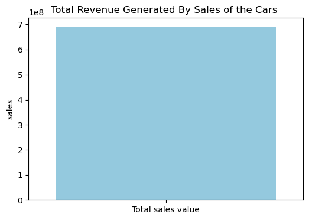

```python
total_profit = df['Price'].sum()
print("total Profit:", total_profit)

plt.figure(figsize=(6,4))
sns.barplot(x=['Total sales value'], y=[total_profit], color='skyblue')
plt.title('Total Revenue Generated By Sales of the Cars ')
plt.ylabel('sales')
plt.show()
```

The above bar graph showing the total revenue gernerated by the sales of cars only from Ford, VW, Toyota, BMW, Porsche brands. this graph represents the revenue generated across all models from that manufacturer brands.The total Revenue generated is 691.289.670 only by this brands which reflets the overall finincal perfomance from the revenue we can say that these are the brands holding highest market share in United kingdom.

This is the single powerfull representation showing the automobile business perfomance into one clear visual

### which fuel type had highest cars sales ?

[output not shown]

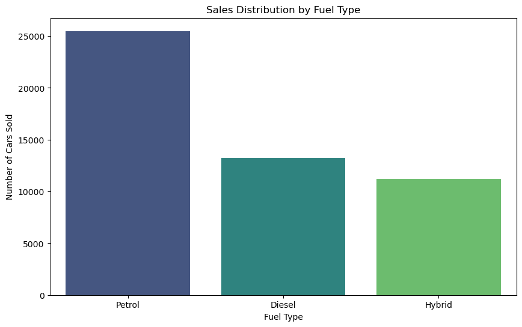

```python
fuel_type_counts = df['Fuel type'].value_counts()

print("Cars sold by Fuel Type:")
print(fuel_type_counts)

plt.figure(figsize=(10, 6))
sns.barplot(x=fuel_type_counts.index, y=fuel_type_counts.values, palette='viridis')

plt.title('Sales Distribution by Fuel Type')
plt.xlabel('Fuel Type')
plt.ylabel('Number of Cars Sold')

plt.show()
```

The above graph explains cars sales by fuel category of three different types. we can clearly see that petrol fuel type is holding highest car sales distribution compared to diesel and hybrid. But Diesel and Hybrid sold very less units of cars compared to petrol.

Petrol fueled sold 25480 units of cars, Diesel fueled sold 13264 units and the least Hybrid powerd sold 11244 units from the total sales. Diesel and Hybrid vehicles sold closely . even by combining both the types can reach the petrol fueled units. so from the graph we can clearly say that petrol fueled vehicles holding the highest market share.

### which brand or manufacture sold more cars ?

```
Distribution of Cars Sold by Manufacturer (Top sold Manufacturers):
Manufacturer
Ford       14956
VW         14906
Toyota     12553
BMW         4964
Porsche     2609
Name: count, dtype: int64
```

[output not shown]

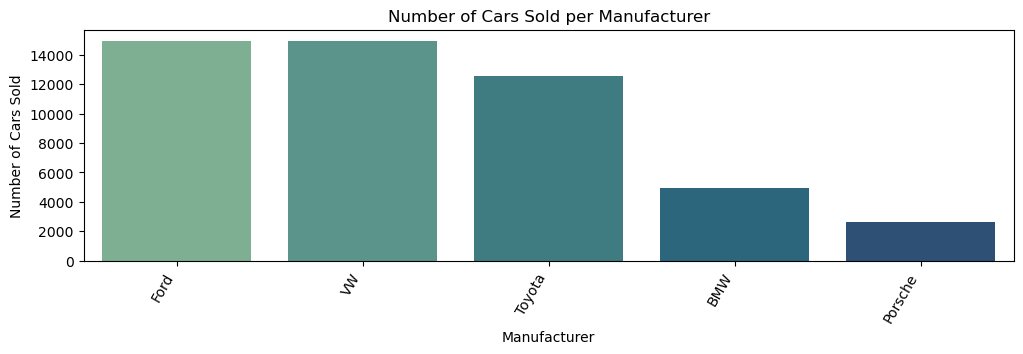

```python
brand_counts = df['Manufacturer'].value_counts()


print("Distribution of Cars Sold by Manufacturer (Top sold Manufacturers):")
print(brand_counts.head(10)) # Displaying top 10 for readability


plt.figure(figsize=(12, 3))

sns.barplot(x=brand_counts.index, y=brand_counts.values, palette='crest', hue=brand_counts.index, legend=False)

plt.title('Number of Cars Sold per Manufacturer')
plt.xlabel('Manufacturer')
plt.ylabel('Number of Cars Sold')
plt.xticks(rotation=60, ha='right')
```

Basesed on the bar chart we can observe the distribution of car sales across five different car brands: Ford, VW, Toyota, BMW and Porsche. The bar chart showing the Ford leads the market with 14956 units ffollowing closly withe brand VW (volkswagen) and respectively by Toyota, BMW and porsche. Porsche and BMW sold very less units 2609 Porsche holds last position in the market and BMW holds the fourth position with the units 4964.

Ford and VW strong perfomance in sales reflects their broad product protofils. Toyota slightly lower figures compared to Ford and VW. overall chart clearly showing the sales of the car brands which manufacturer is leading and which manufacturer is in the last.

### What is the milage share of hybrid car models ?

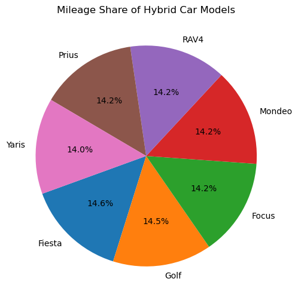

```python
# Filter only hybrid cars
hybrid_cars = df[df["Fuel type"].str.lower() == "hybrid"]

# Group by Model and calculate average mileage
hybrid_mileage = hybrid_cars.groupby("Model")["Mileage"].mean().reset_index()

# Sort by mileage (optional: highest first)
hybrid_mileage = hybrid_mileage.sort_values(by="Mileage", ascending=False)

# Pie chart
plt.figure(figsize=(6,6))
plt.pie(
    hybrid_mileage["Mileage"],
    labels=hybrid_mileage["Model"],
    autopct="%1.1f%%",
    startangle=200
)
plt.title("Mileage Share of Hybrid Car Models")
plt.show()
```

Above pie chats explaing the milage share of hybrid car models. we can clearly see the visual breakdown of how milage distributed across seven different hybrid car models offering a comperative view.

Each part of th pie chart almost distributed equally. Fiest leads with 14.6% followed by Golf at 14.5% while Prius, RAV4, Mondeo, and focus each holding 14.2% of equal share and the Yaris is last. Overall the chart reflects balanced across the hybrid category

### which car gives more milage costly or affordable ?

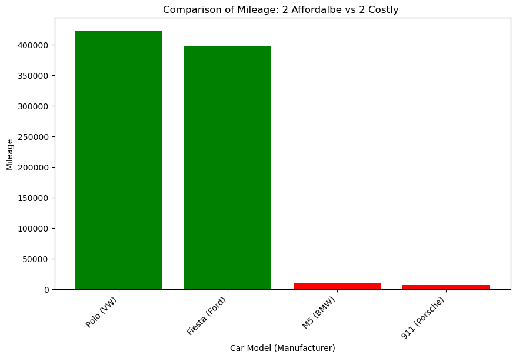

```python
df_sorted = df.sort_values(by="Price", ascending=True)
cheapest_cars = df_sorted.head(5)
costliest_cars = df_sorted.tail(5)
comparison_df = pd.concat([cheapest_cars, costliest_cars])
plt.figure(figsize=(10,6))
plt.bar(comparison_df["Model"] + " (" + comparison_df["Manufacturer"] + ")", comparison_df["Mileage"], color=['green']*5 + ['red']*5)
plt.xticks(rotation=45, ha="right")
plt.title("Comparison of Mileage: 2 Affordalbe vs 2 Costly ")
plt.xlabel("Car Model (Manufacturer)")
plt.ylabel("Mileage")
plt.show()
```

The above bar graph explain about the comprassion between two affordable cars mileage vs two costly cars across different car brands. The affordable car models Polo (VW) and Fiesta (Ford) are represented by green colour bars and costly cars M5 (BMW) and 911 (Porsche) represented in red coloured bars. From the above graph we can clearly see there is lot of difference between the two categories where the affordable cars outperformed the costly ones in milage. from this graph we can clearly understand affordable cars are more fuel efficient compaared to costly cars

### what are the top 5 car models sold among all brands

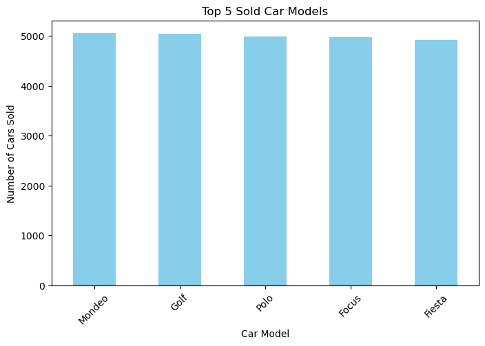

```python
top_models.plot(kind="bar", color="skyblue", figsize=(8,5))
plt.title("Top 5 Sold Car Models")
plt.xlabel("Car Model")
plt.ylabel("Number of Cars Sold")
plt.xticks(rotation=45)
plt.show()
```

the bar chart explains visual comparision of mostly sold top 5 car models from different brands. each model of the cars are represented in light blue coloured bars all bars are approximately at the same height it means all that models sold nearly same units.

This chart is kind of balanced sales across top sold models of cars not a single model significantly outperformed the others in demand or sales

### what are correlation between engine size and milage and other variables ?

```python
df.corr(numeric_only=True)
```

|  | Engine size | Year of manufacture | Mileage | Price |
| --- | --- | --- | --- | --- |
| Engine size | 1.000000 | -0.000670 | 0.004365 | 0.398391 |
| Year of manufacture | -0.000670 | 1.000000 | -0.807643 | 0.714195 |
| Mileage | 0.004365 | -0.807643 | 1.000000 | -0.632817 |
| Price | 0.398391 | 0.714195 | -0.632817 | 1.000000 |

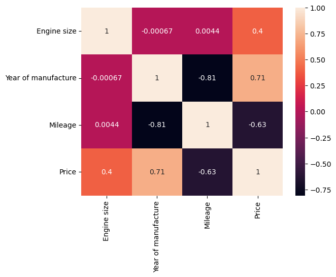

```python
sns.heatmap(df.corr(numeric_only=True),annot=True)
```

This heatmap presents the correlation matrix that explains the relation between four main variables From the heatmap we can observe that the positive correlation between the engine size and price. Bigger engine size leads to increase in the price of the car

Another strong correlation we can observe is the year of manufacture of the car leads to the increase in price. in other words the latest car model costs more than the older

Additionally correlation is the cars which giving more mileage are lower in price which means the affordable cars giving more mileage

finally last correlation is the newer model cars are giving less mileage commpared to old car models

```python
a=df['Manufacturer'].unique()
```

[output not shown]

### what is the total revenue generated by each Brand ?

```python
import warnings
warnings.simplefilter(action='ignore', category=FutureWarning)
```

```
Total Revenue by Manufacturer:
Manufacturer
Toyota     180023821
Ford       159602557
VW         154452715
BMW        121278855
Porsche     75931722
Name: Price, dtype: int64
```

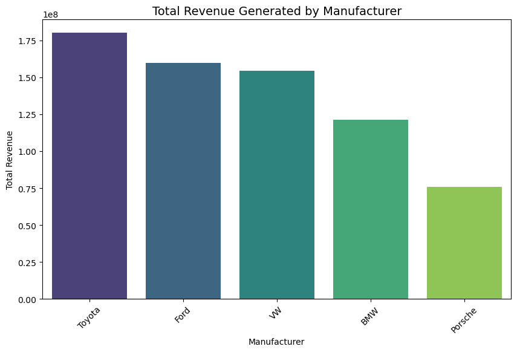

```python
manufacturer_revenue = df.groupby("Manufacturer")["Price"].sum().sort_values(ascending=False)

print("Total Revenue by Manufacturer:")
print(manufacturer_revenue)

plt.figure(figsize=(10,6))
sns.barplot(x=manufacturer_revenue.index, y=manufacturer_revenue.values, palette="viridis")
plt.title("Total Revenue Generated by Manufacturer", fontsize=14)
plt.xlabel("Manufacturer")
plt.ylabel("Total Revenue")
plt.xticks(rotation=45)
plt.show()
```

The bar plot illustrates the total revenue generated by Toyota, Ford, VW, BMW and Porsche. First bar Toyota holding the first place in generating revenue followed by Ford, VW, BMW and finally Porsche which has the lowest revenue generated. Toyota and Ford are the leading companies in generating more profits.

## Recommendations

Reducing purchasing of buying aged vehicles and giving priority to car with recently manufactured years cars when buying these can bring highest resale value for the cars from any manufacturer. running campagin on the luxary cars and big sized engines will may increasee the sale of costly cars also . compare average prices and milage with in each fuel type in every manufacturere company. cars with small engines may give more milage but will have more maintanence. Giving more details about cars like count of the owner change will have major change on price and also including engine CC will help a lot.

## Conclusion

This data clearly shows the car age and milage are the strong predictions for market price while engine size and other features play small roles in the sales of the cars.the newer vehicle with lower milage consistently achieve higher prices. lower milage vehicles will improve pricing and profit. adding more details about vehicles or region information in the future will allow more business strategies. Explaining the importance of bigger sized engines may increase the sales of cars in premium segment cars